# Numerical Optimisation

Dom Owens

19/11/2019

How can we find the optimal value of a function from all feasible solutions? Without loss of generality, we consider minimisation for continuous problems.

The standard form of the constrained problem is
$$\min f(x)$$
$$s.t. g_i(x) \leq 0, i=1,...,m \hspace{} h_j(x) = 0, j=1,...,p$$
though we will focus mainly on unconstrained minimisation.

## Optimisation in One Dimension

Consider this function

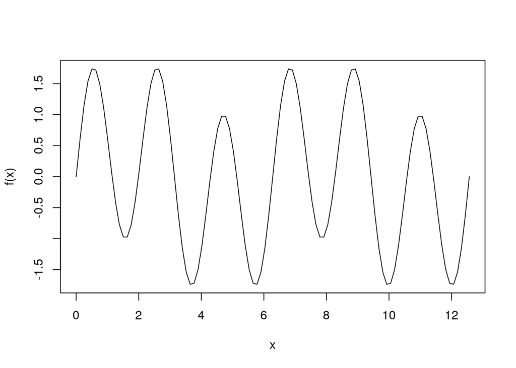

```r
f = function(x) cos(x)*sin(2*x)  + sin(3*x)
curve(f, from=0, to=4*pi)
```

We solve this minimisation with `optimize` which only works for one dimensional problems.

```r
optimize(f, interval=c(0,4*pi))
```

```
## $minimum
## [1] 7.854002
##
## $objective
## [1] -1
```

This finds a local, not nessecarily a global, minimimum using golden section search. One benefit of this is that no derivative needs to be calculated, so works on continous but non-differentiable functions.

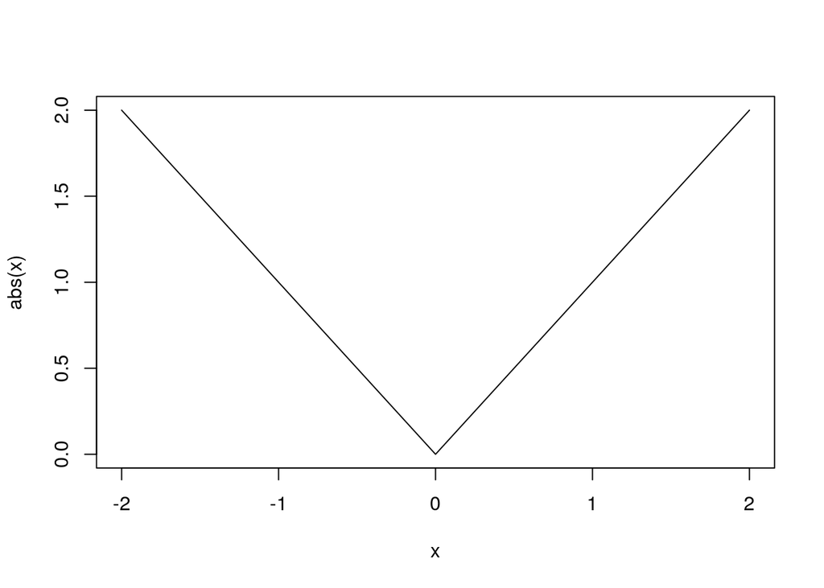

```r
#library(soobench)
#fw <- weierstrass_function(1)
#fw <- function(x){
#  n <- 10
#  a <- 0.9
#  b <- 7
#  y <- 1:n
#  for (i in 1:n) {
#    y[i] <- a^(i-1)*cos(b^(i-1) *pi * x)
#  }
#  sum(y)
#}
#y <-
#curve(fw, -2,2)
curve(abs, from = -2, to = 2)
```

```r
optimize(abs, interval=c(-2,2))
```

```
## $minimum
## [1] 5.551115e-17
##
## $objective
## [1] 5.551115e-17
```

## Newton’s Method

Based on the Taylor expansion, we use the iterative formula
$$x \xleftarrow{} x - \frac{g(x)}{g'(x)}$$

```r
f_sym <- expression(cos(x)*sin(2*x)  + sin(3*x)) #define f
f1_sym <- D(f_sym, 'x') #f'
f1 <- function(x) eval(f1_sym) #f'(x)
f2_sym <- D(f1_sym, 'x') #f''
f2 <- function(x) eval(f2_sym) #f''(x)
x <- 2 #x_0
for (i in 1:6) {
  x <- x - f1(x) / f2(x); cat(x, '\n')
}
```

```
## 0.7602888
## 0.5173089
## 0.5551037
## 0.5551212
## 0.5551212
## 0.5551212
```

This converges in 4 steps to a maximum; this highlights that Newton’s Method does not discriminate between minima and maxima.

## Optimisation in Multiple Dimensions

We delineate the approaches to optimisation into three categories: - **Simplex methods** using only function values - **Gradient methods** using the first derivatives (gradient) - **Newton-type methods** using the second derivatives (Hessian) or an approximation

These are largely implemented by `nlm` or `optim`.

### Simplex Methods

Exemplified by the Nelder-Mead method of direct search. Morphs a $n+1$ vertex in $n$-dimensional space based on the function values at each vertex. This is slow, converges to local minima only, and can converge to non-stationary points.

### Gradient Methods

We iterate on
$$\mathbf{x} \xleftarrow{} \mathbf{x} - t\mathbf{d}$$

where $\mathbf{d}$ is a *descent direction*, and $t$ is a step size (chosen with e.g. line search). This is slow, so isn’t used by the canonical optimisation functions, but is simple. The **Conjugate Gradient** method selects descent directions which are conjugate to the previous direction, avoiding zigzag behaviour. Tends to outperform gradient descent, but not Newton-type methods.

### Newton-type Methods

We iterate on
$$\mathbf{x} \xleftarrow{} \mathbf{x} - [H(f(\boldsymbol{x}))]^{-1} \nabla f(\mathbf{x})$$

We sgould consider that finding $H$ in high dimensions is hard, and inversion is expensive. **Quasi-Newton** methods replace this with a reasonable approximation. BFGS is the most commonly used method in R, which avoids calculating any inverses but does require storing large dense matrices $B_k$ which approximate $H$. The L-BFGS algorithm overcomes storage problems by using a low-dimensional representation of $B_k$.

### Simulated Annealing

The three previous methods discussed were deterministic methods. Simulated Annealing works like the Metropolis-Hastings algorithm, jumping around the function between states according to acceptance probabilities until a minimum is reached. This finds the global minimum, but operates slowly.

# Optimisation Functions in R

We initiate a 2D function for demonstrating some methods.

```r
#install.packages("pracma")
library(pracma) # for meshgrid function
f <- function(x1, x2) cos(x1)*sin(2*x2)  + sin(3*x1*x2) + (x1-x2)^3 #define function to optimise
meshgrid(seq(-2, 2, length=5)) #output coordinate grid
```

```
## $X
##      [,1] [,2] [,3] [,4] [,5]
## [1,]   -2   -1    0    1    2
## [2,]   -2   -1    0    1    2
## [3,]   -2   -1    0    1    2
## [4,]   -2   -1    0    1    2
## [5,]   -2   -1    0    1    2
##
## $Y
##      [,1] [,2] [,3] [,4] [,5]
## [1,]   -2   -2   -2   -2   -2
## [2,]   -1   -1   -1   -1   -1
## [3,]    0    0    0    0    0
## [4,]    1    1    1    1    1
## [5,]    2    2    2    2    2
```

```r
x <- seq(-2, 2, length=101) #store finer grid
grid_XY <- meshgrid(x)
z <- matrix(mapply(f, grid_XY$X, grid_XY$Y), nrow=101) #apply function
min(z) #print minimum
```

```
## [1] -63.14849
```

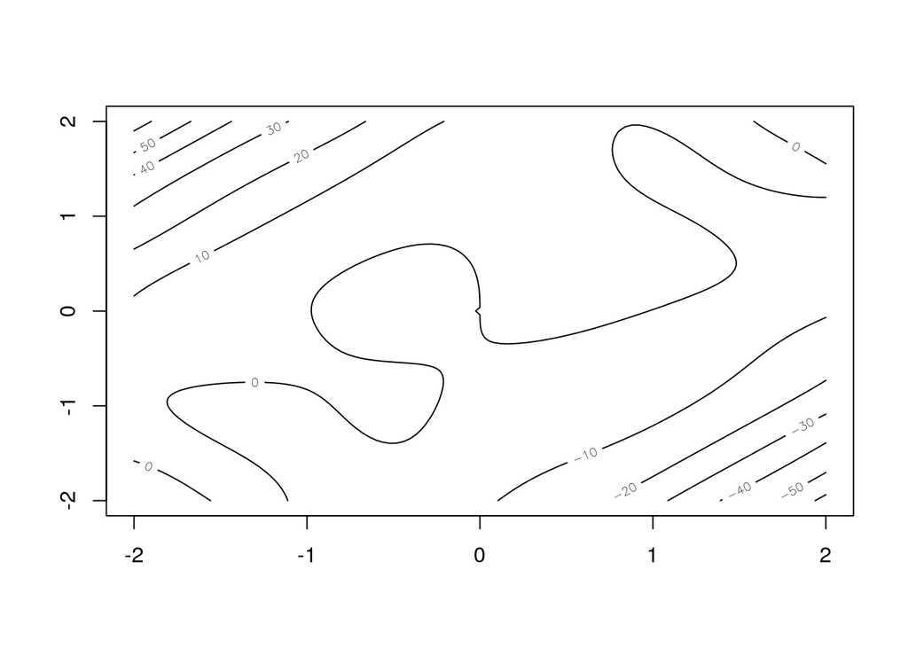

```r
contour(x, x, z) #show contour plot
```

## `nlm`

For Newton-type methods, we require the gradient and Hessian matrix.

```r
f1 <- deriv(expression(cos(x1)*sin(2*x2)  + sin(3*x1*x2) + (x1-x2)^3), namevec = c('x1', 'x2'), function.arg=T, hessian=T) #calculate first and second derivatives
f1(0,0) #evaluate at origin
```

```
## [1] 0
## attr(,"gradient")
##      x1 x2
## [1,]  0  2
## attr(,"hessian")
## , , x1
##
##      x1 x2
## [1,]  0  3
##
## , , x2
##
##      x1 x2
## [1,]  3  0
```

We try `nlm` at two different initial conditions:

```r
nlm(function(x) f1(x[1], x[2]), c(0,0)) #start nlm at (0,0)
```

```
## $minimum
## [1] -0.7844471
##
## $estimate
## [1]  0.1545715 -0.5313069
##
## $gradient
## [1] 6.494805e-13 1.813640e-06
##
## $code
## [1] 2
##
## $iterations
## [1] 15
```

```r
nlm(function(x) f1(x[1], x[2]), c(10, 10),  stepmax = 1000) #start at (10,10)
```

```
## $minimum
## [1] -1.897023
##
## $estimate
## [1]  9.880883 10.120652
##
## $gradient
## [1]  0.02399007 -1.06034777
##
## $code
## [1] 4
##
## $iterations
## [1] 100
```

These find different minima.

If we don’t specify the gradient or Hessian to `nlm`, numerical approximations are used. This impacts accuracy.

```r
nlm(function(x) f(x[1], x[2]), c(10,10)) #start nlm at (0,0) without gradient or Hessian
```

```
## $minimum
## [1] -1.142578e+15
##
## $estimate
## [1] -52271.70  52271.38
##
## $gradient
## [1]  32787751456 -32787784247
##
## $code
## [1] 5
##
## $iterations
## [1] 11
```

## `optim`

The canonical optimisation function in R, `optim`, uses Nelder-Mead by default.

```r
optim(c(0,0), function(x) f(x[1], x[2])) #run optim using Nelder-Mead, starting at origin
```

```
## $par
## [1]  0.1545715 -0.5313072
##
## $value
## [1] -0.7844471
##
## $counts
## function gradient
##      113       NA
##
## $convergence
## [1] 0
##
## $message
## NULL
```

We can alternatively use e.g. conjugate gradients, BFGS, and L-BFGS. In general, BFGS works best:

```r
optim(c(0, 0), function(x) f(x[1], x[2]), method="BFGS") #run optim using BFGS algorithm, starting at origin
```

```
## $par
## [1]  0.1545717 -0.5313071
##
## $value
## [1] -0.7844471
##
## $counts
## function gradient
##       24       10
##
## $convergence
## [1] 0
##
## $message
## NULL
```

Simulated annealing will find the global minimum, but perform poorly. Indeed, we should control the maximum number of iterations.

```r
optim(c(0, 0), function(x) f(x[1], x[2]), method="SANN", control=list(maxit=3000)) #run soptim with simulated annealing, starting at origin, using at most 3000 iterations
```

```
## $par
## [1] -112.0806  131.1809
##
## $value
## [1] -14395271
##
## $counts
## function gradient
##     3000       NA
##
## $convergence
## [1] 0
##
## $message
## NULL
```